# Template — 2. Preprocesamiento y preparación de los datos

**Objetivo:** Transformar los datos limpios obtenidos en el EDA en un formato adecuado para el entrenamiento y evaluación de modelos de aprendizaje automático.

> Para cada subsección encontrarás una celda *Markdown* con instrucciones y una celda de *Python* para tu código.

```python
# Sugerencia: importa aquí librerías comunes para todo el notebook
import pandas as pd
import numpy as np
import joblib
# from sklearn.preprocessing import OneHotEncoder, LabelEncoder, StandardScaler, MinMaxScaler, RobustScaler
# from sklearn.model_selection import train_test_split
# from imblearn.over_sampling import SMOTE  # si usas imblearn

from sklearn.model_selection import train_test_split
from sklearn.ensemble import RandomForestClassifier
from sklearn.metrics import accuracy_score

from sklearn.preprocessing import RobustScaler

import matplotlib.pyplot as plt
import seaborn as sns
import numpy as np

df = pd.read_csv('clean.csv')
```

## 1. Codificación de variables categóricas

- Identificar variables no numéricas que representen categorías.
- Aplicar técnicas de codificación según el modelo a utilizar:
  - **Label Encoding** (para variables **ordinales** o modelos basados en **árboles**).
  - **One-Hot Encoding** (para variables **nominales** sin orden).
  - **Target Encoding** (opcional; usar con cuidado si hay muchas categorías).

### identificando variables no numericas que representan categorias

```python
categorical_cols = df.select_dtypes(include=['object', 'category']).columns

print("Variables no numéricas que representan categorías:")
for col in categorical_cols:
    print(f"- {col}")
```

```
Variables no numéricas que representan categorías:
- PassengerId
- HomePlanet
- Cabin
- Destination
- Name
- Deck
- Side
```

```python
df = df.drop(columns=['PassengerId', 'Name'], errors='ignore')
display(df.head())
```

|  | HomePlanet | CryoSleep | Cabin | Destination | Age | VIP | RoomService | FoodCourt | ShoppingMall | Spa | VRDeck | Transported | Deck | CabinNum | Side |
| --- | --- | --- | --- | --- | --- | --- | --- | --- | --- | --- | --- | --- | --- | --- | --- |
| 0 | Europa | False | B/0/P | TRAPPIST-1e | 39.0 | False | 0.0 | 0.0 | 0.0 | 0.0 | 0.0 | False | B | 0 | P |
| 1 | Earth | False | F/0/S | TRAPPIST-1e | 24.0 | False | 109.0 | 9.0 | 25.0 | 549.0 | 44.0 | True | F | 0 | S |
| 2 | Europa | False | A/0/S | TRAPPIST-1e | 58.0 | True | 43.0 | 3576.0 | 0.0 | 6715.0 | 49.0 | False | A | 0 | S |
| 3 | Europa | False | A/0/S | TRAPPIST-1e | 33.0 | False | 0.0 | 1283.0 | 371.0 | 3329.0 | 193.0 | False | A | 0 | S |
| 4 | Earth | False | F/1/S | TRAPPIST-1e | 16.0 | False | 303.0 | 70.0 | 151.0 | 565.0 | 2.0 | True | F | 1 | S |

### Aplicando tecnica de codificacion segun el modelo a utilizar

## **Explicaciones**

1. ¿Qué modelo vamos a usar? Random Forest (Bosque Aleatorio).¿Por qué? Es un modelo muy robusto para problemas de clasificación binaria (como predecir True/False). A diferencia de la regresión logística, Random Forest no asume relaciones lineales, maneja de forma excelente los valores atípicos (outliers) y no requiere que las variables numéricas (como RoomService o FoodCourt) estén estrictamente normalizadas o estandarizadas, aunque en tu plan de proyecto contemplan hacerlo.
2. ¿Qué técnica de codificación aplicar? Dado que hay varias columnas categóricas (HomePlanet, CryoSleep, Cabin, Destination, VIP), la estrategia de codificación ideal para prepararlas para Random Forest o Regresión Logística es una combinación de técnicas:

Mapeo Binario (Binarización): Para variables que solo tienen dos estados como CryoSleep (dormido o no), VIP (paga servicios especiales o no) y tu variable objetivo Transported. Consiste en transformar True a 1 y False a 0.

One-Hot Encoding (Variables Dummy): Para variables categóricas nominales sin un orden específico y con pocas categorías, como HomePlanet y Destination. Esto crea una columna nueva de ceros y unos para cada planeta o destino.

Transformación y extracción (Alta cardinalidad): Variables como Cabin (número de cabina, cubierta y lado), Name (nombres y apellidos) y PassengerId no deben codificarse directamente porque tienen demasiados valores únicos.

```python
# 1. Binarización de variables booleanas
bool_cols = ['CryoSleep', 'VIP', 'Transported']
for col in bool_cols:
    if col in df.columns:
        df[col] = df[col].astype(int) # Convierte True/False a 1/0

# 2. Extracción de datos de la cabina
if 'Cabin' in df.columns:
    df[['Deck', 'Num', 'Side']] = df['Cabin'].str.split('/', expand=True)
    df = df.drop(columns=['Cabin', 'Num'], errors='ignore')
else:
    print("Warning: 'Cabin' column not found, assuming 'Deck' and 'Side' were already extracted or not applicable.")

# 3. Eliminar variables que no codificaremos por su alta cardinalidad
# Nos aseguramos de eliminar PassengerId y Name
df = df.drop(columns=['PassengerId', 'Name'], errors='ignore')

# 4. One-Hot Encoding para las variables nominales (HomePlanet, Destination, Deck, Side)
categorical_cols = ['HomePlanet', 'Destination', 'Deck', 'Side']
actual_categorical_cols = [col for col in categorical_cols if col in df.columns]
df_encoded = pd.get_dummies(df, columns=actual_categorical_cols, drop_first=True, dtype=int)

# Revisamos las nuevas columnas (Ya no deberían aparecer Name ni PassengerId)
print(df_encoded.head())
```

```
   CryoSleep   Age  VIP  RoomService  FoodCourt  ShoppingMall     Spa  VRDeck  \
0          0  39.0    0          0.0        0.0           0.0     0.0     0.0
1          0  24.0    0        109.0        9.0          25.0   549.0    44.0
2          0  58.0    1         43.0     3576.0           0.0  6715.0    49.0
3          0  33.0    0          0.0     1283.0         371.0  3329.0   193.0
4          0  16.0    0        303.0       70.0         151.0   565.0     2.0

   Transported  CabinNum  ...  Destination_PSO J318.5-22  \
0            0         0  ...                          0
1            1         0  ...                          0
2            0         0  ...                          0
3            0         0  ...                          0
4            1         1  ...                          0

   Destination_TRAPPIST-1e  Deck_B  Deck_C  Deck_D  Deck_E  Deck_F  Deck_G  \
0                        1       1       0       0       0       0       0
1                        1       0       0       0       0       1       0
2                        1       0       0       0       0       0       0
3                        1       0       0       0       0       0       0
4                        1       0       0       0       0       1       0

   Deck_T  Side_S
0       0       0
1       0       1
2       0       1
3       0       1
4       0       1

[5 rows x 22 columns]
```

## 2. Escalado o normalización de variables numéricas

- Analizar si el modelo es **sensible a la escala** (KNN, SVM, regresión, redes).
- Elegir el método adecuado:
  - **Min-Max Scaling** ajusta los valores entre 0 y 1.
  - **Standard Scaling (Estandarización):** convierte los valores a media 0 y desviación estándar 1.
  - **Robust Scaling** usa la mediana y el rango intercuartílico (útil si hay outliers).

```python
# 1. Definimos cuáles son nuestras variables numéricas
num_cols = ['Age', 'RoomService', 'FoodCourt', 'ShoppingMall', 'Spa', 'VRDeck']

# 2. Inicializamos el escalador
# Elegimos RobustScaler porque detectamos muchos outliers en los servicios (gastos)
scaler = RobustScaler()

# 3. Aplicamos el escalado a nuestro dataframe codificado
df_encoded[num_cols] = scaler.fit_transform(df_encoded[num_cols])

# 4. Revisamos cómo quedaron los datos numéricos escalados
print("Datos después de aplicar Robust Scaling:")
print(df_encoded[num_cols].head())
```

```
Datos después de aplicar Robust Scaling:
        Age  RoomService  FoodCourt  ShoppingMall         Spa  VRDeck
0  0.705882     0.000000   0.000000      0.000000    0.000000   0.000
1 -0.176471     2.658537   0.147541      1.136364   10.358491   1.100
2  1.823529     1.048780  58.622951      0.000000  126.698113   1.225
3  0.352941     0.000000  21.032787     16.863636   62.811321   4.825
4 -0.647059     7.390244   1.147541      6.863636   10.660377   0.050
```

## 3. Creación de nuevas variables (*Feature Engineering*)

- A partir de fechas, obtener año, mes, día o día de la semana.
- Calcular proporciones, diferencias o variables agregadas.
- Combinar variables relacionadas o crear indicadores binarios.

```python
# Escribe tu código aquí

# Definimos las columnas que representan gastos
columnas_gastos = ['RoomService', 'FoodCourt', 'ShoppingMall', 'Spa', 'VRDeck']

# 1. Calcular variable agregada: Gasto Total
# Sumamos todos los gastos por pasajero (axis=1 suma por filas)
df_encoded['Total_Spent'] = df_encoded[columnas_gastos].sum(axis=1)

# 2. Crear indicador binario: ¿Hizo algún gasto?
# Será 1 si el gasto total es mayor a 0, y 0 si no gastó nada
df_encoded['Has_Expenses'] = (df_encoded['Total_Spent'] > 0).astype(int)

# Revisamos cómo quedaron las nuevas variables
print("Nuevas variables creadas con éxito:")
print(df_encoded[['RoomService', 'FoodCourt', 'Total_Spent', 'Has_Expenses']].head())
```

```
Nuevas variables creadas con éxito:
   RoomService  FoodCourt  Total_Spent  Has_Expenses
0     0.000000   0.000000     0.000000             0
1     2.658537   0.147541    15.400932             1
2     1.048780  58.622951   187.594845             1
3     0.000000  21.032787   105.532744             1
4     7.390244   1.147541    26.111799             1
```

```python
# Se guarda el escaler
joblib.dump(scaler, 'robust_scaler.pkl')

# Columnas para los modelos
feature_columns = df_encoded.drop(columns=['Transported']).columns.tolist()
joblib.dump(feature_columns, 'feature_columns.pkl')

print(feature_columns)
```

[output not shown]

## 4. Selección de variables relevantes (*Feature Selection*)

- Identificar *features* útiles mediante:
  - Estadística: correlación, ANOVA, chi-cuadrado.
  - Modelos: importancia de variables (árboles, *Random Forest*, XGBoost).
  - Métodos recursivos: **RFE**.
- Eliminar variables **redundantes** o con **alta correlación** (> 0.9).

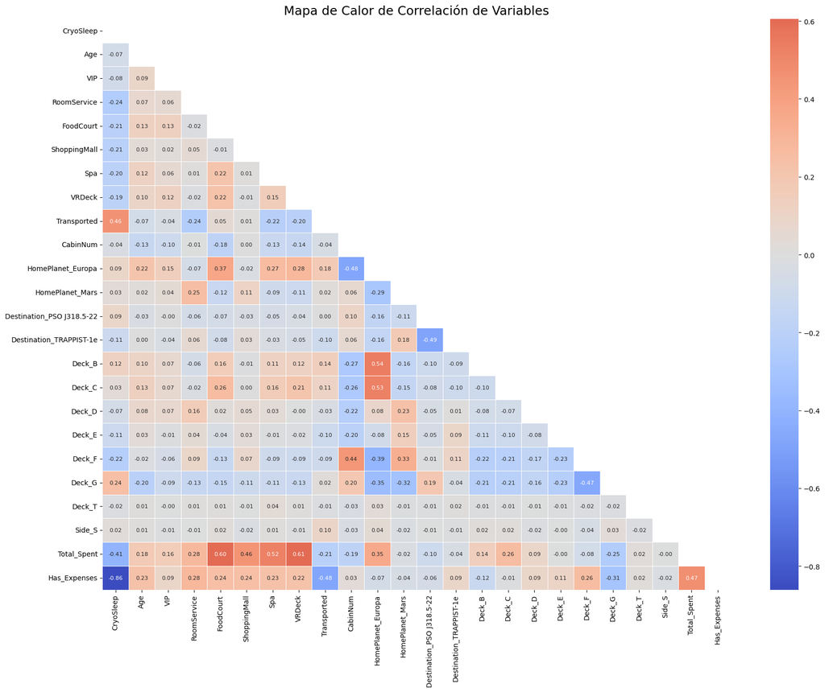

```python
import numpy as np
import matplotlib.pyplot as plt
import seaborn as sns

# 1. Calcular la matriz de correlación
corr_matrix = df_encoded.corr()

# 2. Crear una máscara para ocultar el triángulo superior (evita información duplicada)
# Esto hace que el gráfico se vea como una escalera
mask = np.triu(np.ones_like(corr_matrix, dtype=bool))

# 3. Configurar el tamaño de la figura (más grande para mayor legibilidad)
plt.figure(figsize=(18, 14))

# 4. Dibujar el mapa de calor
sns.heatmap(corr_matrix,
            mask=mask,
            annot=True,          # Muestra el valor numérico
            fmt=".2f",           # Redondea a 2 decimales
            cmap='coolwarm',     # Colores: azul para negativos, rojo para positivos
            center=0,            # El blanco será exactamente el 0 (sin correlación)
            linewidths=0.5,      # Líneas de separación entre cuadros
            annot_kws={"size": 8}) # Tamaño de letra de los números

plt.title("Mapa de Calor de Correlación de Variables", fontsize=18)
plt.tight_layout()
plt.show()
```

## 5. Tratamiento del desbalance de clases (si aplica)

- Verificar si existen clases con muy pocos ejemplos respecto a otras. Aplicar técnicas según sea necesario::
  - **Oversampling** (p. ej., SMOTE).
  - **Undersampling**.
  - **Class weights** en el modelo.
- Documenta tus decisiones y justificaciones.

```
Distribución de clases (%):
Transported
1    50.362361
0    49.637639
Name: proportion, dtype: float64
```

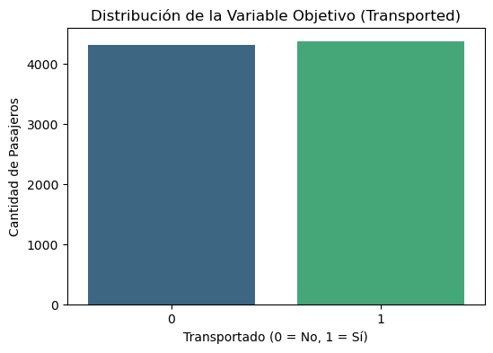

```python
#Decisión: No se aplicarán técnicas de tratamiento de desbalance (oversampling, undersampling o class weights).
#Justificación: Al analizar la variable objetivo (Transported), se observó que las clases se encuentran naturalmente balanceadas.
#La distribución es de aproximadamente 50.4% para la clase mayoritaria y 49.6% para la clase minoritaria.
#Dado que no existe una asimetría significativa,
#los modelos de clasificación no sufrirán un sesgo de aprendizaje hacia ninguna de las dos clases
#y evaluarán el rendimiento de manera equitativa.

#Sin embargo, dejamos un código que nos permitirá verificar y visualizar el balance:

# 1. Calcular los porcentajes exactos de la variable objetivo
balance = df_encoded['Transported'].value_counts(normalize=True) * 100
print("Distribución de clases (%):")
print(balance)

# 2. Generar el gráfico para documentar
plt.figure(figsize=(6, 4))
sns.countplot(data=df_encoded, x='Transported', palette='viridis')
plt.title("Distribución de la Variable Objetivo (Transported)")
plt.xlabel("Transportado (0 = No, 1 = Sí)")
plt.ylabel("Cantidad de Pasajeros")
plt.show()
```

## 6. Almacenamiento del dataset preparado

Guarda los datos transformados para reutilizarlos sin repetir todo el proceso.

- Genera un archivo con datos procesados, por ejemplo: data_for_modeling.csv.

```python
# Guardar el dataset procesado en un archivo CSV


df_encoded.to_csv('data_for_modeling.csv', index=False)

print("¡Dataset guardado exitosamente como 'data_for_modeling.csv'!")
```

```
¡Dataset guardado exitosamente como 'data_for_modeling.csv'!
```